# Exploring the Impact of Aging Populations and Deprivation on Cardiovascular Health and Antihypertensive Prescriptions in Scotland

Brian Kim

2024-11-01

## Introduction

Cardiovascular disesase (CVD) refers to group of conditions affecting the heart and blood vessels. CVD is the leading cause of death both globally and in Scotland [(British Heart Foundation, 2018)](https://www.bhf.org.uk/for-professionals/healthcare-professionals/data-and-statistics/the-cvd-challenge/the-cvd-challenge-in-scotland), emphasizing the need to better understand their risk factors and treatment trends. The causes of CVD are multifactorial. Among these, hypertension (high blood pressure) is commonly recognized as one of the strongest and most prevalent risk factor for CVD, with substantial evidence supporting its causal relationship [(Fuchs and Whelton, 2020)](https://pubmed.ncbi.nlm.nih.gov/31865786/).

This project aimed to explore trends in antihypertensive prescriptions across Scottish council areas, focusing on the relationship between prescribing patterns, age demographics, and deprivation levels. Specifically, it examined whether areas with larger elderly populations or higher deprivation scores, based on the 2020 Scottish Index of Multiple Deprivation (SIMD), were associated with increased antihypertensive prescription. For this report, “elderly population” refers to individuals aged 65 and older in accordance with common health guidelines. All datasets used in this project and their respective data dictionaries were taken from **Public Health Scotland Open Data**, which can be accessed here: https://www.opendata.nhs.scot/

The time scope this report covered was limited to 2022, mainly because the most recent heart disease mortality data available was between January 1 to December 31, 2022. Additionally, the most recent GP demographic dataset for 2022 was from October, which is why the October 2022 prescription dataset was chosen for analysis.

```r
#Loading required libraries
library(tidyverse)
library(janitor)
library(gt)
library(here)
```

## Data Preparation for Analysis

### Refining Prescription Data

To start with, the 2022 October prescription dataset was loaded and cleansed. Given the large variety of antihypertensive drugs, the scope was narrowed down to just calcium channel blockers, including both the brand and generic names. Finally, dataset was refined to include only the columns of interest. The Health Board code SB0806 was removed filtered out because it represents drugs prescribed in ambulances.

```r
#Loading 2022 october prescription data
prescriptions_data <- read_csv("https://www.opendata.nhs.scot/dataset/84393984-14e9-4b0d-a797-b288db64d088/resource/bd7bc2cf-4de5-4711-bd5a-9e3b77305453/download/pitc202210.csv") %>%
  clean_names()

#Defining calcium channel blockers to filter in data
calcium_channel_blockers <- c("Norvasc", "Amlodipine", "Diltiazem", "Cardizem", "Tiazac", "Plendil", "Felodipine", "DynaCirc", "Isradipine", "Cardene", "Nicardipine", "Sular", "Nisoldipine",  "Verelan", "Covera HS", "Isoptin SR", "Verapamil", "Procardia XL", "Adalat CC", "Nifedipine") %>%
  toupper() #Convert all names to uppercase

#Filtering the Prescription data
filtered_prescriptions <- prescriptions_data %>%
  filter(str_detect(bnf_item_description, paste(calcium_channel_blockers, collapse = "|"))) %>%
  filter(hbt != "SB0806") %>% # Exclude ambulance prescriptions (hbt = SB0806)
  select(gp_practice, hbt, bnf_item_description, paid_quantity) #filtering only the columns we're interested in
```

### Merging GP Population Demographic Data

The dataset with GP population demographic was then loaded and processed to identify the number of elderly population. This was achieved by summing the population over 65 years old for each GP practice. The resulting dataset was then joined with the filtered prescription dataset based on GP codes.

```r
#Loading GP demographic data
gp_demographic_data <- read_csv("https://www.opendata.nhs.scot/dataset/e3300e98-cdd2-4f4e-a24e-06ee14fcc66c/resource/2c7dcb55-c83a-44bd-9128-47d1d6f339ba/download/practice_listsizes_oct2022-open-data.csv") %>%
  clean_names()

#Calculating number of elderly population per GP
filtered_gp <- gp_demographic_data %>%
  mutate(over_65 = ages65to74 + ages75to84 + ages85plus) %>%
  select(practice_code, hb, hscp, over_65) %>%
  group_by(practice_code) %>%
  summarise(over_65_total = sum(over_65, na.rm = TRUE))  #Summing the total elderly population per gp practice

#Joining GP demographic data to prescription data
prescriptions_age <- filtered_prescriptions %>%
  left_join(filtered_gp, by = join_by(gp_practice == practice_code))
```

### Merging Healthboard and Council Area Data

Then, Health Board (HB) names dataset was loaded to add the corresponding HB names to the prescription dataset. The HB Codes were renamed and selected to match the prescription dataset, and two dataset were joined.

```r
#Loading Health Board name data
healthboards_name <- read_csv("https://www.opendata.nhs.scot/dataset/9f942fdb-e59e-44f5-b534-d6e17229cc7b/resource/652ff726-e676-4a20-abda-435b98dd7bdc/download/hb14_hb19.csv") %>%
  clean_names()

#Preparing HB name data for joining
filtered_hb_name <- healthboards_name %>%
  rename(hbt = hb) %>%
  select(hbt, hb_name)

#Joining HB names with prescription dataset by HB code
prescriptions_age_hb <- prescriptions_age %>%
  left_join(filtered_hb_name, join_by(hbt))
```

Then, the council area (CA) information was added. The CA_HB dataset, which links council areas to health boards, was loaded and processed to ensure the correct mapping of council area names to their respective healthboards. The council area names were grouped and concatenated by their respective healthboard code before being joined with the prescription dataset. This step was done because multiple council areas share the same HB code. Thus, joining data by HB code created many new observations (duplicates) that were not part of the original dataset.

```r
#Loading Council Area, Health Board data
ca_hb <- read_csv("https://www.opendata.nhs.scot/dataset/9f942fdb-e59e-44f5-b534-d6e17229cc7b/resource/967937c4-8d67-4f39-974f-fd58c4acfda5/download/ca11_ca19.csv") %>%
  clean_names()

#Refining CA data for joining
filtered_ca_hb <- ca_hb %>%
  select(hb_name, ca_name, ca) %>%
  group_by(hb_name) %>%
  summarize(council_area = paste(unique(ca_name), collapse = ", ")) # Combine council area names that are under same healthboard

#Joining Council Area data with the prescription data
prescriptions_age_hb_ca <- prescriptions_age_hb %>%
  left_join(filtered_ca_hb, by = join_by(hb_name))
```

### Merging CVD Mortality Outcome data

Lastly, data from the **Scottish Heart Disease Statistics** dataset, specifically the **Heart Disease Mortality by Health Board** section, was added. The dataset was filtered to include only deaths from 2022 and individuals aged 65 and older. Then, mortality count were summed by health board regions, ending with the total number of deaths for individuals aged 65+ within each council area.

```r
#Loading CVD outcome data
heart_mortality_data <- read_csv("https://www.opendata.nhs.scot/dataset/0e17f3fc-9429-48aa-b1ba-2b7e55688253/resource/dc0512a8-eb49-43b9-84f1-17ef95365d57/download/hd_mortalitybyhbr.csv") %>%
  clean_names()

#joining heart disease outcome by hb code
filtered_heart_data <- heart_mortality_data %>%
  select(year, hbr, number_of_deaths, age_group) %>%
  filter(age_group %in% c("75plus years", "65-74 years")) %>% #filtering for CVD death only in elder population
  filter(year == 2022) %>%
  group_by(hbr) %>%
  summarise(over_65_total_death = sum(number_of_deaths, na.rm = TRUE)) #Summing for elder population mortality per HB
```

Then, the population of individuals aged 65 and older was calculated for each concatenated council area. This was done by grouping the demographic data by council area and summing the over-65 population (over_65_total) for each council area. These population metrics were then joined with the prescription dataset. Some council areas, including Na h-Eileanan Siar, Orkney Islands, and Shetland Islands, reported zero cardiovascular deaths. These regions were excluded from the analysis, as this likely reflects data collection issues or reporting errors rather than an accurate representation of mortality rates.

```r
#Creating a column that has number of population for merged council area
total_over65_ca <- prescriptions_age_hb_ca %>%
  select(council_area, gp_practice, over_65_total) %>%
  distinct() %>% #remove duplicate
  group_by(council_area) %>%
  summarise(over65_CA = sum(over_65_total, na.rm = TRUE)) #Total number of elder populatino per council areas under same HB

#Final Joined Data
joined_data_final <- prescriptions_age_hb_ca %>%
  left_join(total_over65_ca, by = "council_area") %>%  #joining to add 65+ populatino for CA
  left_join(filtered_heart_data, by = join_by(hbt == hbr)) %>%  #joining to add mortality rate
  filter(over_65_total_death != 0) %>% #Removed Council Area with 0 CVD Death Reports
  group_by(council_area) %>%
  summarise(
    paid_quantity = sum(paid_quantity, na.rm = TRUE),
    over65_CA = first(over65_CA), #only picks the first value instead of summing because each row is already a sum
    over65_total_death = first(over_65_total_death, na_rm = TRUE)
  )
```

## Data Analysis

### Relationship Between Elderly Population, Prescriptions, and Cardiovascular Outcomes

With the complete dataset, a scatter plot was generated to visualize the relationship between the elderly population, antihypertensive prescriptions, and cardiovascular outcomes.

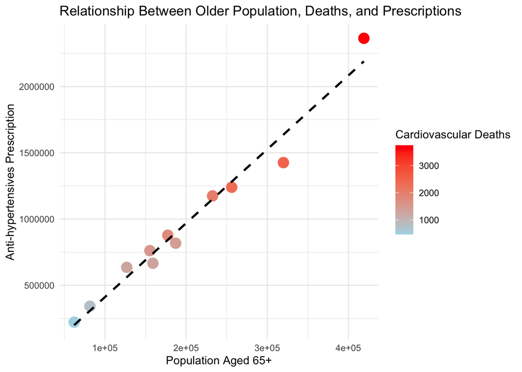

```r
#Creating a scatter plot
ggplot(joined_data_final, aes(x = over65_CA, y = paid_quantity, color = over65_total_death)) +
  geom_point(alpha = 1, size = 4.5) +  # Scatter plot with size and color encoding
  geom_smooth(method = "lm", se = FALSE, color = "black", linetype = "dashed", alpha = 0.3, show.legend = FALSE) +  # Regression line
  scale_color_gradient(low = "lightblue", high = "red") +  # Gradient for color
  labs(
    title = "Relationship Between Older Population, Deaths, and Prescriptions",
    x = "Population Aged 65+",
    y = "Anti-hypertensives Prescription",
    color = "Cardiovascular Deaths"
  ) +
  theme_minimal()
```

The results demonstrated a clear linear relationship, with regions containing larger elderly populations exhibiting higher prescription volumes. Cardiovascular deaths, represented by color intensity (red indicating higher mortality), also tended to increase alongside prescription volumes. While the overall trend aligned with expectations, the deviations observed suggested potential disparities in healthcare access or effectiveness.

### Deprivation and Its Relationship With CVD

To further investigate factors influencing this relationship, deprivation was examined as a potential cause of disparities in CVD outcomes. Previous research has shown that individuals living in the most deprived communities are 30% more likely to have high blood pressure. [(Public Health England, 2019)](https://www.gov.uk/government/publications/health-matters-preventing-cardiovascular-disease/health-matters-preventing-cardiovascular-disease) Additionally, it is also known that CVD occurs more frequently in lower-income, more deprived areas.

To investigate this, the **Scottish Index of Multiple Deprivation (SIMD)** data was used. SIMD ranks regions in Scotland from most deprived (rank 1) to least deprived (rank 5) based on factors such as access to services, crime, education, employment, health, housing, and income. This analysis aimed to determine whether regions with higher deprivation scores exhibit trends in prescription volumes and CVD deaths.

SIMD dataset was loaded and cleaned for analysis. Since the SIMD data includes quintile ranks for deprivation, the dataset was filtered and summarized by Health Board (HB) to calculate the average deprivation rank (mean_simd_rank) for each Health Board. This allowed for comparisons at the council area level. The mean was rounded to 4 decimal digits because the differences were quite minimal. SIMD data was first joined with Health Board names to align it with the prescription and council area datasets.

```r
#Loading SIMD data
SIMD <- read_csv("https://www.opendata.nhs.scot/dataset/78d41fa9-1a62-4f7b-9edb-3e8522a93378/resource/acade396-8430-4b34-895a-b3e757fa346e/download/simd2020v2_22062020.csv") %>%
  clean_names()

#Filtering out SIMD and linking to CA
SIMD_Filtered <- SIMD %>%
  left_join(filtered_hb_name, by = join_by(hb == hbt)) %>%
  select(hb_name, simd2020v2ca_quintile) %>%
  group_by(hb_name) %>%
  summarise(mean_simd_rank = round(mean(simd2020v2ca_quintile, na.rm = TRUE), 4)) #Calculating mean SIMD score per council area
```

Next, the council area dataset was linked to the summarized SIMD data, joining deprivation scores with demographic and prescription trends.

```r
#Joining SIMD to prescription
SiMD_CA_relation <- SIMD_Filtered %>%
  left_join(filtered_ca_hb, by = join_by(hb_name))

joined_data_final_CA <- joined_data_final %>%
  left_join(SiMD_CA_relation, by = join_by(council_area))
```

Using the updated dataset, a new column called prescriptions_per_death was created. This column was calculated by dividing the total number of prescriptions (paid_quantity) by the total number of cardiovascular deaths among the population aged 65 and older.

```r
#making a table
joined_data_final_CA %>%
  mutate(prescriptions_per_death = round(paid_quantity / over65_total_death, 1)) %>%
  select(
    council_area,
    over65_CA,
    paid_quantity,
    over65_total_death,
    prescriptions_per_death,
    mean_simd_rank
  ) %>%
  arrange(desc(prescriptions_per_death)) %>%
  gt() %>%
  tab_header(
    title = "Prescriptions per Cardiovascular Death by Council Area"
  ) %>%
  fmt_number(columns = c(paid_quantity, over65_total_death), decimals = 0) %>%
  fmt_number(columns = prescriptions_per_death, decimals = 1) %>% #rounding to one decimal points
  cols_label(
    council_area = "Council Area",
    over65_CA = "Elderly Population",
    paid_quantity = "Total Prescriptions",
    over65_total_death = "Cardiovascular Deaths",
    prescriptions_per_death = "Prescriptions per Death",
    mean_simd_rank = "Mean Deprivation Score"
  ) %>%
  tab_style(
    style = cell_text(weight = "bold"), #Column labels Bold
    locations = cells_column_labels()
  ) %>%
  tab_source_note( #Data Source
    source_note = "Data source: Public Health Scotland Open Data."
  )
```

Prescriptions per Cardiovascular Death by Council Area

| Council Area | Elderly Population | Total Prescriptions | Cardiovascular Deaths | Prescriptions per Death | Mean Deprivation Score |
| --- | --- | --- | --- | --- | --- |
| East Renfrewshire, Inverclyde, Renfrewshire, West Dunbartonshire, East Dunbartonshire, Glasgow City | 419090 | 2,363,841 | 3,744 | 631.4 | 2.9698 |
| Moray, Aberdeen City, Aberdeenshire | 232556 | 1,174,958 | 2,000 | 587.5 | 2.9680 |
| East Lothian, Midlothian, City of Edinburgh, West Lothian | 319908 | 1,426,069 | 2,460 | 579.7 | 2.9926 |
| Perth and Kinross, Angus, Dundee City | 187088 | 817,960 | 1,444 | 566.5 | 2.9773 |
| South Lanarkshire, North Lanarkshire | 256144 | 1,240,121 | 2,352 | 527.3 | 2.9522 |
| Highland, Argyll and Bute | 159070 | 666,867 | 1,298 | 513.8 | 2.9336 |
| Fife | 155308 | 762,029 | 1,516 | 502.7 | 2.9798 |
| Clackmannanshire, Falkirk, Stirling | 126798 | 636,026 | 1,270 | 500.8 | 2.9361 |
| East Ayrshire, North Ayrshire, South Ayrshire | 177408 | 878,384 | 1,770 | 496.3 | 2.9960 |
| Scottish Borders | 61972 | 222,627 | 470 | 473.7 | 2.9580 |
| Dumfries and Galloway | 81448 | 342,787 | 762 | 449.9 | 3.0199 |

Data source: Public Health Scotland Open Data.

### Correlation Analysis

Correlation analyses were conducted to explore the relationships between the variables in this study. Pearson’s correlation analysis was chosen as it is well-suited for continuous variables, providing a measure of the linear relationship between them [(Sereno, 2021)](https://www.analyticsvidhya.com/blog/2021/03/comparison-of-pearson-and-spearman-correlation-coefficients/).

The first test evaluated whether regions with larger elderly populations had higher prescription volumes, while the second and third tests examined how deprivation influenced prescription rates and cardiovascular mortality.

```r
#Correlation test: Older population vs. Prescriptions
cor_test_age <- cor.test(joined_data_final_CA$over65_CA, joined_data_final_CA$paid_quantity, method = "pearson")
cor_test_age
```

```
##
##  Pearson's product-moment correlation
##
## data:  joined_data_final_CA$over65_CA and joined_data_final_CA$paid_quantity
## t = 17.546, df = 9, p-value = 2.872e-08
## alternative hypothesis: true correlation is not equal to 0
## 95 percent confidence interval:
##  0.9440043 0.9964031
## sample estimates:
##       cor
## 0.9856953
```

```r
# Correlation test: Deprivation vs. Prescriptions
cor_test_deprivation <- cor.test(joined_data_final_CA$mean_simd_rank, joined_data_final_CA$paid_quantity, method = "pearson")
cor_test_deprivation
```

```
##
##  Pearson's product-moment correlation
##
## data:  joined_data_final_CA$mean_simd_rank and joined_data_final_CA$paid_quantity
## t = -0.010279, df = 9, p-value = 0.992
## alternative hypothesis: true correlation is not equal to 0
## 95 percent confidence interval:
##  -0.6020638  0.5976772
## sample estimates:
##          cor
## -0.003426159
```

```r
# Correlation test: Deprivation vs. Cardiovascular Deaths
cor_test_cvd <- cor.test(joined_data_final_CA$mean_simd_rank, joined_data_final_CA$over65_total_death, method = "pearson")
cor_test_cvd
```

```
##
##  Pearson's product-moment correlation
##
## data:  joined_data_final_CA$mean_simd_rank and joined_data_final_CA$over65_total_death
## t = -0.007615, df = 9, p-value = 0.9941
## alternative hypothesis: true correlation is not equal to 0
## 95 percent confidence interval:
##  -0.6014974  0.5982476
## sample estimates:
##          cor
## -0.002538317
```

The analysis revealed a strong positive correlation between the elderly population and antihypertensive prescriptions (r = 0.98, p < 0.001), indicating that regions with larger elderly populations tend to have significantly higher prescription volumes. However, the relationship between deprivation and prescriptions showed no meaningful linear correlation (r = -0.004, p = 0.992), suggesting that deprivation levels alone do not predict antihypertensive prescription rates. Similarly, the correlation between deprivation and cardiovascular deaths was negligible (r = -0.003, p = 0.994). These findings are counterintuitive, as deprived areas are typically associated with poorer health outcomes and higher cardiovascular mortality. This lack of significant correlation maybe due to small data sample size or differences in regional reporting practices, which could underestimate the expected relationships.

## Conclusion

This report explored the relationships between antihypertensive prescriptions, elderly populations, deprivation, and cardiovascular health across council areas in Scotland. The findings showed a strong link between larger elderly populations and higher prescription volumes, reflecting the growing healthcare needs of aging communities. However, deprivation did not show a clear connection to either prescription rates or cardiovascular deaths. The analysis was limited to one year and a single month of data, and the deprivation measure combines multiple factors, which may obscure specific influences. Future research could explore these trends over time, consider additional factors like medication adherence, and investigate how deprivation interacts with aging to affect health outcomes. This report highlights the importance of addressing the needs of older populations while continuing to explore broader social determinants of health.

## References

British Heart Foundation (2018). The CVD Challenge in Scotland. [online] British Heart Foundation. Available at: https://www.bhf.org.uk/for-professionals/healthcare-professionals/data-and-statistics/the-cvd-challenge/the-cvd-challenge-in-scotland.

Fuchs, F.D. and Whelton, P.K. (2020). High Blood Pressure and Cardiovascular Disease. Hypertension, [online] 75(2), pp.285–292. doi:https://doi.org/10.1161/HYPERTENSIONAHA.119.14240.

Kimenai, D.M., Pirondini, L., Gregson, J., Prieto, D., Pocock, S.J., Perel, P., Hamilton, T., Welsh, P., Campbell, A., Porteous, D.J., Hayward, C., Sattar, N., Mills, N.L. and Shah, A.S.V. (2022). Socioeconomic Deprivation: An Important, Largely Unrecognized Risk Factor in Primary Prevention of Cardiovascular Disease. Circulation, 146(3), pp.240–248. doi:https://doi.org/10.1161/circulationaha.122.060042.

Public Health England (2019). Health matters: preventing cardiovascular disease. [online] GOV.UK. Available at: https://www.gov.uk/government/publications/health-matters-preventing-cardiovascular-disease/health-matters-preventing-cardiovascular-disease.

Sereno (2021). Pearson vs Spearman Correlation | Comparison b/w Spearman & Pearson. [online] Analytics Vidhya. Available at: https://www.analyticsvidhya.com/blog/2021/03/comparison-of-pearson-and-spearman-correlation-coefficients/.